# Intro to DS - Logit Regression

GWU Intro to Data Science DATS 6101

2022-11-11

# HW Assignment - Logit Regression

We have the historic Titanic dataset to study here. You can use `Titanic` on api.regression.fit for the dataset, or the local file `Titanic.csv`. The variables in the dataset are:

- `survival`: Survival, 0 = No, 1 = Yes
- `pclass`: Ticket class, 1 = 1st, 2 = 2nd, 3 = 3rd
- `sex`: Gender / Sex
- `age`: Age in years
- `sibsp`: # of siblings / spouses on the Titanic
- `parch`: # of parents / children on the Titanic
- `ticket`: Ticket number (for superstitious ones)
- `fare`: Passenger fare
- `embarked`: Port of Embarkment C: Cherbourg, Q: Queenstown, S: Southampton

The questions listed here are the basic guidelines, not the only goal, in this homework. For example, after you load the dataframe, even though the question does not ask you to look at the structure of the dataframe, you most likely should. You are given fewer and fewer “specific to-dos” in the homework, as you are getting more familiar with the data analysis process. Calculate and figure out the necessary info needed in the analysis, even though the questions might not ask for them explicitly. When you look at your own work, you should find it convincing, answering the questions and technically sound.

## Titanic Tragedy Dataset

### Question 1

**Import the dataset into R**  
Import the dataset into R, and call it `titanic_orig`, and explore it little to get the overall picture of the dataset. Eventually we would like to see what affected `survival` in the tragedy.

```r
titanic_orig = data.frame(read.csv("Titanic.csv"))
# titanic_orig
```

### Question 2

**Age**  
One of the independent variables we will use to model `survival` is `age`. How many missing values are there for the variable `age`? If not too many, let’s just subset those out.

```r
cat("Missing values in 'age' column are: ", sum(is.na(titanic_orig$age)))
```

```
## Missing values in 'age' column are:  177
```

```r
titanic_orig = subset(titanic_orig, !is.na(age))
# titanic_orig.head()
```

### Question 3

**More clean up**  
While we are cleaning up the data, if we were to use `sibsp` and `parch` in our analysis, even though they are legitimately ratio-level variables, we might not expect doubling the number of siblings necessarily double the effects on survival. For this reason, let’s change these two variables to factor variables. Also change the other ones that you find imported as the wrong data type.

```r
titanic_orig$survived = factor(titanic_orig$survived)
titanic_orig$sibsp = factor(titanic_orig$sibsp)
titanic_orig$parch = factor(titanic_orig$parch)
titanic_orig$pclass = factor(titanic_orig$pclass)
# titanic_orig
```

## Pre-logistic Regression

### Question 4

**Survival and age**  
Before using our newly learned technique of logistic regression, let’s go old school, and use some prior knowledge to try find an answer. Does the data support that `age` affects `survival`?

```r
# age_contable = xtabs(~ survived + age, data = titanic_orig)
# age_contable = table(titanic_orig$survived, titanic_orig$age)
# age_contable

# chisq.test(age_contable)
# t.test(titanic_orig$age, titanic_orig$survived)
t.test(age ~ survived, data=titanic_orig)
```

```
##
##  Welch Two Sample t-test
##
## data:  age by survived
## t = 2, df = 599, p-value = 0.04
## alternative hypothesis: true difference in means between group 0 and group 1 is not equal to 0
## 95 percent confidence interval:
##  0.0916 4.4734
## sample estimates:
## mean in group 0 mean in group 1
##            30.6            28.3
```

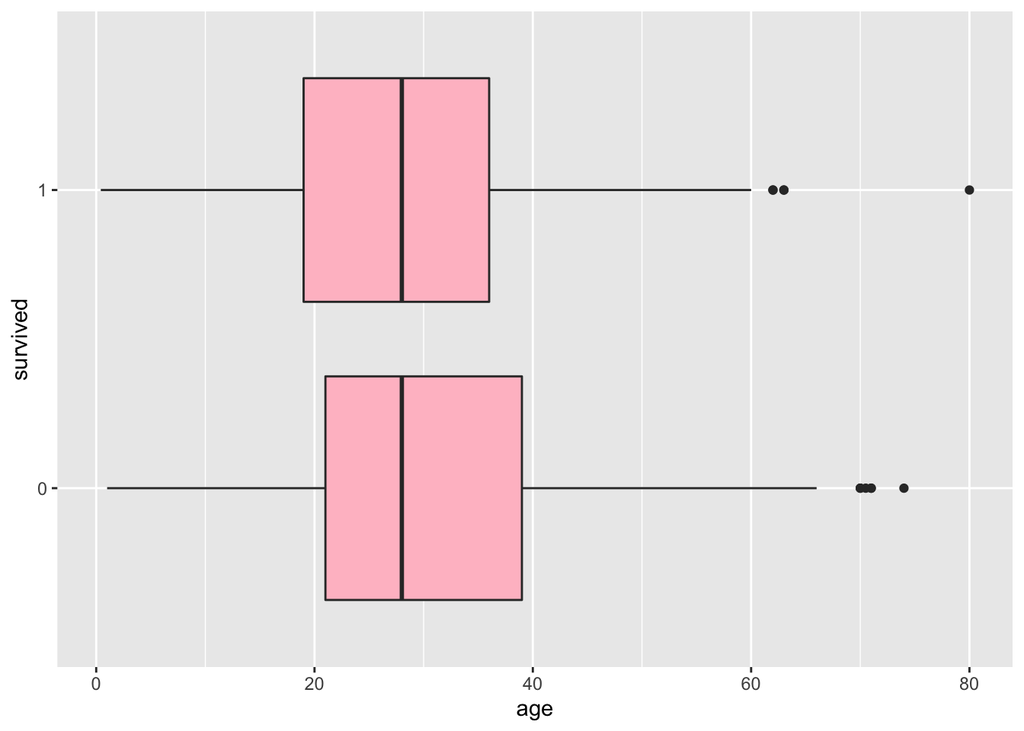

```r
library(ggplot2)
ggplot(titanic_orig, aes(x=age, y=survived)) + geom_boxplot(fill="pink")
```

### Question 5

**Survival and gender**  
Similarly, does the data support that `sex` has an effect on `survival`?

```r
sex_contable = table(titanic_orig$survived, titanic_orig$sex)
sex_contable
```

```
##
##     female male
##   0     64  360
##   1    197   93
```

```r
chisq.test(sex_contable)
```

```
##
##  Pearson's Chi-squared test with Yates' continuity correction
##
## data:  sex_contable
## X-squared = 205, df = 1, p-value <2e-16
```

Above Chi-Square test has p-value of <0.05 so we will reject the null hypothesis (H0). So, survival is not independent of sex data.

### Question 6

**Survival and pclass**  
Another big question is, does the data support ticket class `pclass` has an effect on `survival`?

```r
pclass_contable = table(titanic_orig$survived, titanic_orig$pclass)
pclass_contable
```

```
##
##       1   2   3
##   0  64  90 270
##   1 122  83  85
```

```r
chisq.test(pclass_contable)
```

```
##
##  Pearson's Chi-squared test
##
## data:  pclass_contable
## X-squared = 93, df = 2, p-value <2e-16
```

## Logistic Regression

### Question 7

**Survival and age + pclass**  
Now let us build a logit model with `age + pclass` as predictors, and analyze the results. Is the model a good one? Support your answer with appropriate model evaluation(s). Comment on statistical significant of coefficients, accuracy/confusion matrix, McFadden’s value, ROC/AUC, …

```r
model1 = glm(survived ~ age + pclass, family = "binomial", data = titanic_orig)
summary(model1)
```

```
##
## Call:
## glm(formula = survived ~ age + pclass, family = "binomial", data = titanic_orig)
##
## Deviance Residuals:
##    Min      1Q  Median      3Q     Max
## -2.152  -0.847  -0.608   1.003   2.393
##
## Coefficients:
##             Estimate Std. Error z value Pr(>|z|)
## (Intercept)  2.29601    0.31763    7.23  4.9e-13 ***
## age         -0.04175    0.00674   -6.20  5.7e-10 ***
## pclass2     -1.13753    0.23758   -4.79  1.7e-06 ***
## pclass3     -2.46956    0.24018  -10.28  < 2e-16 ***
## ---
## Signif. codes:  0 '***' 0.001 '**' 0.01 '*' 0.05 '.' 0.1 ' ' 1
##
## (Dispersion parameter for binomial family taken to be 1)
##
##     Null deviance: 964.52  on 713  degrees of freedom
## Residual deviance: 827.16  on 710  degrees of freedom
## AIC: 835.2
##
## Number of Fisher Scoring iterations: 4
```

```r
loadPkg("ModelMetrics")
# confusionMatrix(admitLogit)
xkabledply(confusionMatrix(actual=model1$y, predicted=model1$fitted.values), title = "Confusion matrix from Logit Model" )
```

Confusion matrix from Logit Model

| 1 | 2 |
| --- | --- |
| 344 | 138 |
| 80 | 152 |

Above confusion matrix gives accuracy of 0.695, which is low.

```r
loadPkg("pROC") # receiver operating characteristic curve, gives the diagnostic ability of a binary classifier system as its discrimination threshold is varied. The curve is on sensitivity/recall/true-positive-rate vs false_alarm/false-positive-rate/fall-out.
prob=predict(model1, type = "response" )
titanic_orig$prob=prob
h <- roc(survived~prob, data=titanic_orig)
auc(h) # area-under-curve prefer 0.8 or higher.
```

```
## Area under the curve: 0.745
```

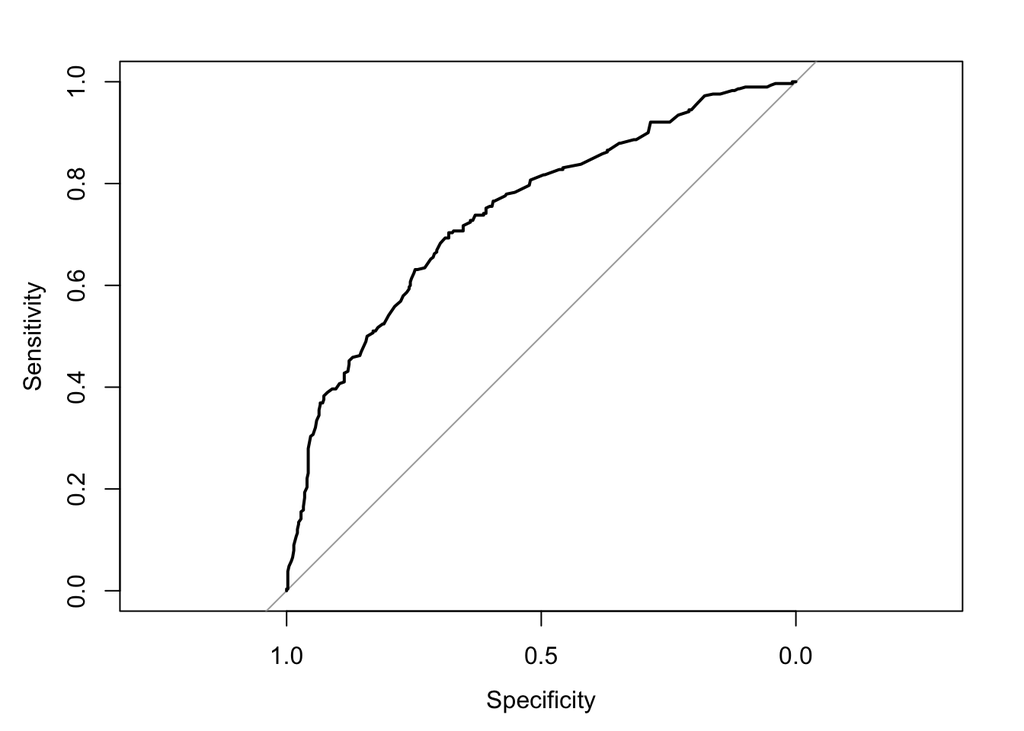

```r
plot(h)
```

We are getting ROC-AUC score of 0.745, which is less than 0.8. The above model is not a good fit.

```r
library(pscl)
pR2(model1)
```

```
## fitting null model for pseudo-r2
```

```
##      llh  llhNull       G2 McFadden     r2ML     r2CU
## -413.582 -482.258  137.352    0.142    0.175    0.236
```

McFadden’s value for above model is 0.142. So predictors used (age and pclass) are only explaining 14% of variance, which is low.

Evaluation of model using confusion metrics, accuracy score, ROC/AUC score, and McFadden’s Value tells that above model is not a good fit and predictors used are not enough to explain the variance.

### Question 8

**More features**  
Can we improve the model? Let us also throw in `sex` as a predictor. How’s the model now? Comment on deviance tests for model comparions, statistical significant of coefficients, accuracy/confusion matrix, McFadden’s value, ROC/AUC, …

```r
model2 = glm(survived ~ age + pclass + sex, family = "binomial", data = titanic_orig)
summary(model2)
```

```
##
## Call:
## glm(formula = survived ~ age + pclass + sex, family = "binomial",
##     data = titanic_orig)
##
## Deviance Residuals:
##    Min      1Q  Median      3Q     Max
## -2.730  -0.678  -0.395   0.648   2.466
##
## Coefficients:
##             Estimate Std. Error z value Pr(>|z|)
## (Intercept)  3.77701    0.40112    9.42  < 2e-16 ***
## age         -0.03699    0.00766   -4.83  1.4e-06 ***
## pclass2     -1.30980    0.27807   -4.71  2.5e-06 ***
## pclass3     -2.58063    0.28144   -9.17  < 2e-16 ***
## sexmale     -2.52278    0.20739  -12.16  < 2e-16 ***
## ---
## Signif. codes:  0 '***' 0.001 '**' 0.01 '*' 0.05 '.' 0.1 ' ' 1
##
## (Dispersion parameter for binomial family taken to be 1)
##
##     Null deviance: 964.52  on 713  degrees of freedom
## Residual deviance: 647.28  on 709  degrees of freedom
## AIC: 657.3
##
## Number of Fisher Scoring iterations: 5
```

```r
xkabledply(confusionMatrix(actual=model2$y, predicted=model2$fitted.values), title = "Confusion matrix from Logit Model")
```

Confusion matrix from Logit Model

| 1 | 2 |
| --- | --- |
| 356 | 83 |
| 68 | 207 |

```r
prob=predict(model2, type = "response" )
titanic_orig$prob=prob
h <- roc(survived~prob, data=titanic_orig)
auc(h) # area-under-curve prefer 0.8 or higher.
```

```
## Area under the curve: 0.852
```

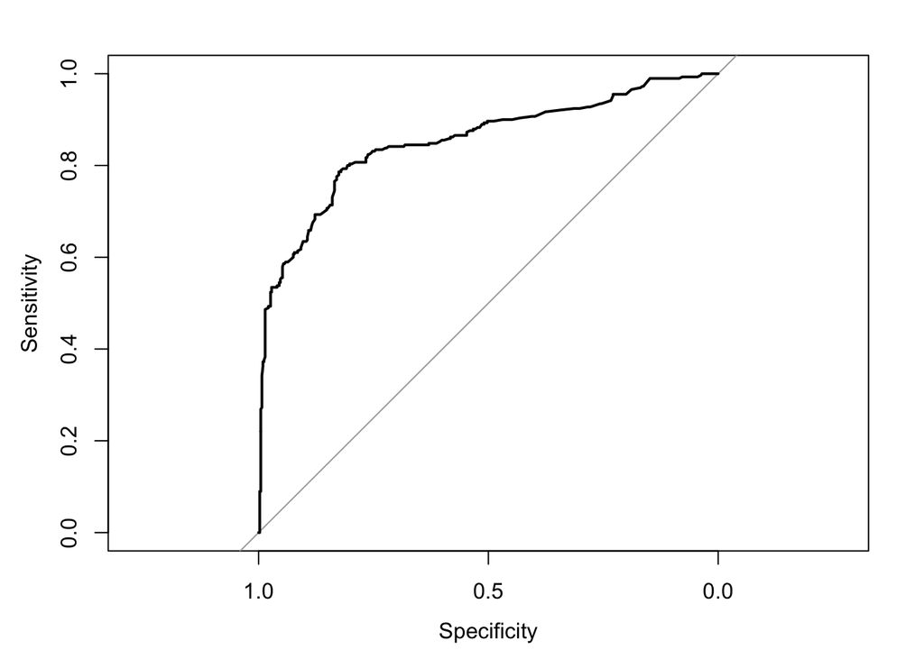

```r
plot(h)
```

```r
pR2(model2)
```

```
## fitting null model for pseudo-r2
```

```
##      llh  llhNull       G2 McFadden     r2ML     r2CU
## -323.642 -482.258  317.233    0.329    0.359    0.484
```

Evaluation of model using confusion metrics, accuracy score, ROC/AUC score, and McFadden’s Value tells that above model is a good fit and predictors used are improving the variance.

### Question 9

**Sample Predictions**  
According to the last model, what is the probability of survival for a female, age 10, second class passenger? And a male, age 20, first class passenger?

```r
titanic_samp_1 <- with(titanic_orig, data.frame(sex="female", age = 10, pclass= "2"))
titanic_samp_1$Survivalp <- predict(model2, newdata = titanic_samp_1, type = "response")
titanic_samp_1
```

```
##      sex age pclass Survivalp
## 1 female  10      2     0.891
```

```r
# newdata1 <- data.frame(sex = "female", age = 10, pclass = 2) # new data frame with 1 row
# predict(model2, newdata = newdata1)
titanic_samp_2 <- with(titanic_orig, data.frame(sex="male", age = 20, pclass= "1"))
titanic_samp_2$Survivalp <- predict(model2, newdata = titanic_samp_2, type = "response")
titanic_samp_2
```

```
##    sex age pclass Survivalp
## 1 male  20      1     0.626
```

## Interpretation

### Question 10

**Summary**  
With all the results you obtained above, how would you present a high-level summary of the findings? Are the results surprising or expected? We discovered that Sex (‘sex’), Age (‘age’), and the class of the passenger seat (‘pclass’) all affect the passenger’s likelihood of survival (‘survived’). This is true not only of the Titanic, but of every catastrophe. Women and children are always prioritized when it comes to rescue passengers. Then there are some who can afford to upgrade to higher passenger classes. Adult males who are “poor” are given the least priority. As a result, the outcomes of this analysis were as predicted.